# Practice Activity, Local Notebook: Visualize on Your Laptop

**GSB 5544 · Computing and Machine Learning for Business Analytics**

This is the **second** notebook of the practice activity. Open it in **Positron, on your laptop**. Do not upload it to SageMaker.

**Before you start**, your `week_7` folder must contain this notebook and the three files you downloaded in step 6:

- `ca_coop_tmax_monthly_2015_2024.csv`
- `timing_summary_remote.csv`
- `remote_measurements.json`

In Positron: **File → Open Folder** and choose your course folder, then open this notebook from `week_7`. If the notebook asks for a kernel (top right), choose the Python you use for this course.

Every code cell starts with `# RUNS ON: laptop (Positron)`. That comment is a label. It does not move the code. The setup cell checks where this kernel really is. Cells with `____` have a blank to fill before you run them. If a cell stops with `NameError: name '____' is not defined`, you ran it before filling in its blank; fill the blank and run it again.

## The workflow, with the part you have finished

| Step | What you do | Where you are | Which computer runs code | Where the data is |
| --- | --- | --- | --- | --- |
| 1 | Sign in to your own AWS account | Browser, AWS website | none | S3 (NOAA’s public bucket) |
| 2 | Open and start your SageMaker space | Browser, SageMaker Studio | none yet | S3 |
| 3 | Read NOAA data from S3 | **Remote notebook** (JupyterLab tab) | **SageMaker** | S3 → SageMaker’s RAM |
| 4 | Filter, transform, aggregate | **Remote notebook** | **SageMaker** | SageMaker’s RAM |
| 5 | Save a small summary CSV | **Remote notebook** | **SageMaker** | SageMaker’s disk |
| 6 | Download the summary | Browser, JupyterLab file browser | none (a file copy) | SageMaker’s disk → your laptop’s disk |
| 7 | Open it and make the chart | **Local notebook** (Positron) | **your laptop** | laptop’s disk → laptop’s RAM |
| 8 | Save your work and stop the space | Positron, then browser | none | your laptop’s disk; SageMaker’s disk |

Steps 1 to 6 are done. You are at step 7.

```python
# RUNS ON: laptop (Positron)
%pip install -q pandas pyarrow s3fs psutil matplotlib      # harmless if already present

import os
import json
import time
import socket
import psutil
import pandas as pd
import matplotlib.pyplot as plt

BUCKET = "noaa-ghcn-pds"


def human(n, base=1000):
    """Turn a byte count into a readable string. base=1000 gives KB/MB/GB; base=1024 gives KiB/MiB/GiB."""
    units = ["B", "KB", "MB", "GB", "TB", "PB"] if base == 1000 else ["B", "KiB", "MiB", "GiB", "TiB", "PiB"]
    for unit in units:
        if n < base:
            return f"{n:,.1f} {unit}"
        n /= base
    return f"{n:,.1f} (huge)"


def where_am_i():
    """Report which computer this kernel is really on. A RUNS ON comment cannot do that."""
    on_sagemaker = (os.path.exists("/opt/ml/metadata/resource-metadata.json")
                    or os.path.expanduser("~") == "/home/sagemaker-user")
    place = "SageMaker (remote)" if on_sagemaker else "not SageMaker (probably your laptop)"
    print("Computer name   :", socket.gethostname())
    print("This looks like :", place)
    return place


def machine_report(work_dir="."):
    """Measure the computer running this cell. Disk numbers are for the filesystem that holds work_dir."""
    vm = psutil.virtual_memory()
    du = psutil.disk_usage(work_dir)
    return {
        "computer name":                    socket.gethostname(),
        "physical CPU cores":               psutil.cpu_count(logical=False),   # may be None on some virtual machines
        "logical CPUs (vCPUs in the cloud)": psutil.cpu_count(logical=True),
        "total RAM (GB)":                   round(vm.total / 1e9, 1),
        "available RAM right now (GB)":     round(vm.available / 1e9, 1),
        "work disk, total (GB)":            round(du.total / 1e9, 1),
        "work disk, free (GB)":             round(du.free / 1e9, 1),
    }


if where_am_i() == "SageMaker (remote)":
    print()
    print("NOTE: this notebook is written to run on your laptop, in Positron, and this kernel is on SageMaker.")
    print("      Download this file and open it in Positron instead.")
```

```
ERROR: Invalid requirement: '#': Expected package name at the start of dependency specifier
    #
    ^
```

```
Computer name   : Lenovo
This looks like : not SageMaker (probably your laptop)
```

Check that the three downloaded files are where this notebook can see them.

```python
# RUNS ON: laptop (Positron)
NEEDED = ["ca_coop_tmax_monthly_2015_2024.csv", "timing_summary_remote.csv", "remote_measurements.json"]
missing = [name for name in NEEDED if not os.path.exists(name)]

print("This notebook is running in:", os.getcwd())
if missing:
    print("MISSING:", missing)
    print("Move them from your Downloads folder into the folder above, then run this cell again.")
else:
    print("All three downloaded files are here.")
    with open("remote_measurements.json") as f:
        REMOTE = json.load(f)
```

```
This notebook is running in: c:\Users\devin\OneDrive\Desktop\GSB-5544-Fall-2026-DA\practice_activities\Week 7 Part 2
All three downloaded files are here.
```

# Part A · The workflow, continued

## Step 7. Open the summary in Positron and make the chart

*You are in: the local notebook, in Positron. Code runs: on your laptop. Data moves: laptop’s disk → laptop’s RAM.*

The file you are about to read was computed on another computer from data you never downloaded. Fill in the function that reads a CSV.

```python
# RUNS ON: laptop (Positron)
small = pd.read_csv("ca_coop_tmax_monthly_2015_2024.csv")
DOWNLOADED_BYTES = os.path.getsize("ca_coop_tmax_monthly_2015_2024.csv")

print(small.shape, "read from a file of", human(DOWNLOADED_BYTES))
small.head()
```

```
(120, 5) read from a file of 2.7 KB
```

|  | year | month | stations | station_days | mean_tmax_c |
| --- | --- | --- | --- | --- | --- |
| 0 | 2015 | 1 | 245 | 7143 | 16.39 |
| 1 | 2015 | 2 | 244 | 6483 | 19.54 |
| 2 | 2015 | 3 | 245 | 7127 | 22.28 |
| 3 | 2015 | 4 | 243 | 6893 | 22.01 |
| 4 | 2015 | 5 | 243 | 7036 | 22.79 |

Draw one line per year: month on the x-axis, mean daily high on the y-axis. Label the chart for what it is: the **mean of daily highs across reporting California cooperative-network stations**, not a statewide temperature.

Fill in the two column names.

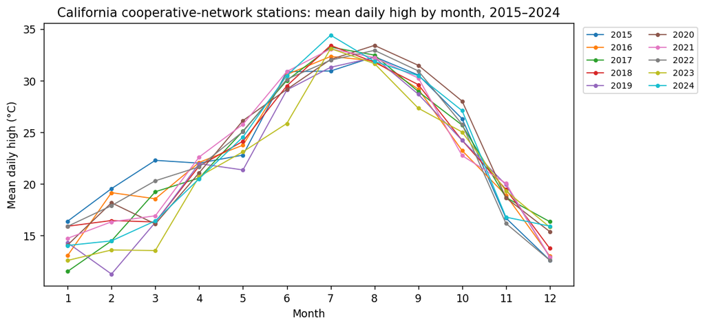

```python
# RUNS ON: laptop (Positron)
fig, ax = plt.subplots(figsize=(9, 4.5))
for year, rows in small.groupby("year"):
    ax.plot(rows["month"], rows["mean_tmax_c"], marker="o", markersize=3, linewidth=1, label=str(year))

ax.set_xticks(range(1, 13))
ax.set_xlabel("Month")
ax.set_ylabel("Mean daily high (°C)")
ax.set_title("California cooperative-network stations: mean daily high by month, 2015–2024")
ax.legend(ncol=2, fontsize=8, loc="upper left", bbox_to_anchor=(1.01, 1))
fig.savefig("ca_coop_tmax_monthly.png", dpi=150, bbox_inches="tight")
plt.show()
```

## Two machines, side by side

`machine_report()` measures the computer running this cell: your laptop. The remote machine’s numbers come from the file you downloaded. Fill in the function call.

```python
# RUNS ON: laptop (Positron)
LOCAL_MACHINE = machine_report()

resources = pd.DataFrame({"laptop": LOCAL_MACHINE, "SageMaker (remote)": REMOTE["machine"]})
resources
```

|  | laptop | SageMaker (remote) |
| --- | --- | --- |
| computer name | Lenovo | default |
| physical CPU cores | 10 | 1 |
| logical CPUs (vCPUs in the cloud) | 12 | 2 |
| total RAM (GB) | 14.6 | 4.0 |
| available RAM right now (GB) | 0.7 | 1.6 |
| work disk, total (GB) | 1023.0 | 5.3 |
| work disk, free (GB) | 789.8 | 5.2 |

Read the table carefully. “Physical CPU cores” and “logical CPUs” are different things, and a cloud vCPU is a logical CPU. The work-disk rows describe each computer’s own disk; neither is S3.

## Four sizes of the same data

```python
# RUNS ON: laptop (Positron)
w = REMOTE["workflow"]
sizes = pd.DataFrame(
    {
        "where": ["S3 (NOAA's bucket)", "SageMaker's RAM", "SageMaker's disk", "your laptop's disk"],
        "size":  [human(w["source bytes in S3"]), human(w["largest DataFrame bytes"]),
                  human(w["summary CSV bytes"]), human(DOWNLOADED_BYTES)],
    },
    index=["source files, ten years", "largest one-year DataFrame", "exported summary CSV", "downloaded summary CSV"],
)
print(f'Rows read remotely: {w["rows read"]:,}   Rows in the summary: {w["summary rows"]}')
sizes
```

```
Rows read remotely: 46,067,495   Rows in the summary: 120
```

|  | where | size |
| --- | --- | --- |
| source files, ten years | S3 (NOAA's bucket) | 157.9 MB |
| largest one-year DataFrame | SageMaker's RAM | 730.0 MB |
| exported summary CSV | SageMaker's disk | 2.7 KB |
| downloaded summary CSV | your laptop's disk | 2.7 KB |

# Part B · A fair timing test, local half

This is the same `timing_job()` as in the remote notebook, character for character: one year, the same columns, the same filter, the same transformation, the same aggregation. Do not edit it.

For this test only, your laptop reads the 2024 slice straight from S3. That is deliberate: both machines must do the same job for the comparison to mean anything. It is a small read. It is **not** the workflow; in the workflow the remote machine did the reading.

```python
# RUNS ON: laptop (Positron)
TIMING_YEAR = 2024
TIMING_COLUMNS = ["ID", "DATE", "DATA_VALUE", "Q_FLAG"]


def timing_job():
    """Read one slice from S3, then summarize it. Returns the summary and the two measured times."""
    t0 = time.perf_counter()
    raw = pd.read_parquet(
        f"s3://{BUCKET}/parquet/by_year/YEAR={TIMING_YEAR}/ELEMENT=TMAX/",
        columns=TIMING_COLUMNS,
        storage_options={"anon": True},
    )
    t1 = time.perf_counter()                                    # reading ends here

    keep = raw[raw["ID"].str.startswith("USC0004") & raw["Q_FLAG"].isna()]
    daily = pd.DataFrame({
        "date":   pd.to_datetime(keep["DATE"].astype(str), format="%Y%m%d"),
        "tmax_c": keep["DATA_VALUE"] / 10,
    })
    summary = (daily.groupby("date")["tmax_c"]
                    .agg(stations="count", mean_tmax_c="mean")
                    .round({"mean_tmax_c": 2})
                    .reset_index())
    t2 = time.perf_counter()                                    # processing ends here

    times = {
        "read seconds":    round(t1 - t0, 2),
        "process seconds": round(t2 - t1, 2),
        "rows read":       len(raw),
        "summary rows":    len(summary),
    }
    return summary, times
```

```python
# RUNS ON: laptop (Positron)
LOCAL_TIMING = []
for run in (1, 2):
    local_summary, times = timing_job()
    LOCAL_TIMING.append({"machine": "laptop", "run": run, **times})
    print(f"run {run}: {times}")
```

```
run 1: {'read seconds': 3.96, 'process seconds': 0.73, 'rows read': 4369887, 'summary rows': 366}
run 2: {'read seconds': 1.49, 'process seconds': 0.56, 'rows read': 4369887, 'summary rows': 366}
```

**First, check that both machines computed the same thing.** A timing comparison between two different answers is meaningless. Fill in the file that holds the remote machine’s result.

```python
# RUNS ON: laptop (Positron)
remote_summary = pd.read_csv("timing_summary_remote.csv", parse_dates=["date"])

same_shape  = local_summary.shape == remote_summary.shape
same_days   = bool((local_summary["date"].values == remote_summary["date"].values).all()) if same_shape else False
same_counts = bool((local_summary["stations"].values == remote_summary["stations"].values).all()) if same_shape else False
max_gap     = float((local_summary["mean_tmax_c"] - remote_summary["mean_tmax_c"]).abs().max()) if same_shape else float("nan")

print("Same shape          :", same_shape, local_summary.shape, remote_summary.shape)
print("Same dates          :", same_days)
print("Same station counts :", same_counts)
print("Largest difference in mean_tmax_c:", max_gap, "°C")
print("EQUIVALENT" if (same_shape and same_days and same_counts and max_gap < 0.011) else "NOT EQUIVALENT: do not interpret the timings until you know why")
```

```
Same shape          : True (366, 3) (366, 3)
Same dates          : True
Same station counts : True
Largest difference in mean_tmax_c: 0.0 °C
EQUIVALENT
```

If the result is not equivalent, the usual cause is that NOAA updated the archive between your two runs, or that one notebook’s `timing_job()` was edited. Rerun both halves close together.

**Then compare the measured times.**

```python
# RUNS ON: laptop (Positron)
timing = pd.DataFrame(LOCAL_TIMING + REMOTE["timing"]).set_index(["machine", "run"])
timing["total seconds"] = (timing["read seconds"] + timing["process seconds"]).round(2)
timing
```

| machine | run | read seconds | process seconds | rows read | summary rows | total seconds |
| --- | --- | --- | --- | --- | --- | --- |
| laptop | 1 | 3.96 | 0.73 | 4369887 | 366 | 4.69 |
|  | 2 | 1.49 | 0.56 | 4369887 | 366 | 2.05 |
| SageMaker (remote) | 1 | 0.87 | 1.14 | 4369887 | 366 | 2.01 |
|  | 2 | 0.86 | 1.06 | 4369887 | 366 | 1.92 |

## Interpret your own results

Answer from the numbers in your tables, not from what you expected. Two or three sentences each.

**T1.** On which machine was **reading** faster, and by how much? Reading includes the network trip from S3 and decoding the files. Which of those do you think explains the difference you saw, given where each computer is?

*Your answer:* Reading was faster on SageMaker: 0.87 s vs. 3.96 s on run 1 (3.09 s faster) and 0.86 s vs. 1.49 s on run 2 (0.63 s faster, about 1.7× quicker). I think the network trip explains the difference, not decoding, because my laptop processed the data faster (T2), so it should decode at least as fast. My laptop pulled the 14.9 MB 2024 slice from S3 over my home internet, while SageMaker pulled it over AWS’s own network (my space was in us-east-2 and the bucket is in us-east-1, so SageMaker’s read crossed regions but stayed inside AWS).

**T2.** On which machine was **processing** faster? Look at the resource table: does the difference in CPUs and RAM account for it?

*Your answer:* Processing was faster on my laptop: 0.73 s vs. 1.14 s on run 1 and 0.56 s vs. 1.06 s on run 2 (about 1.9× faster). My laptop has far more resources (10 physical cores / 12 logical CPUs and 14.6 GB RAM vs. SageMaker’s 1 core / 2 vCPUs and 4.0 GB), but I don’t think core count or RAM is the whole story: this pandas filter and group-by mostly uses one core, and my laptop actually had less RAM free at that moment (0.7 GB vs. 1.6 GB). More likely, each of my laptop’s cores is simply faster than the small cloud instance’s.

**T3.** Compare run 1 and run 2 on each machine. What changed, and what does that tell you about trusting a single timing?

*Your answer:* On my laptop, run 2 read in 1.49 s instead of 3.96 s (about 62% less time) and processed in 0.56 s instead of 0.73 s, while on SageMaker the runs barely changed (read 0.87 → 0.86 s, process 1.14 → 1.06 s). The first run pays one-time warm-up costs, like opening the connection to S3 and loading code, and that mattered most over my slower home connection. A single timing, especially a first run, can be misleading, so a test should be repeated before drawing conclusions.

**T4.** For this small job, was the remote machine worth using for speed alone? What would have to be different about the job for your answer to change?

*Your answer:* No. On run 2 the totals were nearly tied (SageMaker 1.92 s vs. laptop 2.05 s, only 0.13 s apart), and my laptop actually processed faster. The answer would change if the job read much more data from S3, like all ten years (157.9 MB of source files and 46,067,495 rows), where SageMaker’s faster reading adds up, or if the data were too large for my laptop’s RAM or disk, or if we used a larger cloud machine.

# The five questions

Answer each in one or two sentences, with specifics from this activity.

1. **Where is the original data stored?**

   *Your answer:* In NOAA’s public S3 bucket, `noaa-ghcn-pds`, as a Parquet copy of the GHCN-Daily archive in AWS region us-east-1. The ten years of daily-high (TMAX) files we used total 157.9 MB.
2. **Which computer performed the analysis in Part A?**

   *Your answer:* The SageMaker JupyterLab space `gsb5544` (computer name `default`, 2 vCPUs, 4.0 GB RAM) read, filtered, and summarized 46,067,495 rows in about 51 seconds.
3. **What did I download, and how big was it compared with what the remote machine read?**

   *Your answer:* I downloaded the summary `ca_coop_tmax_monthly_2015_2024.csv` (2.7 KB, 120 rows), plus two small files, `timing_summary_remote.csv` (7.7 KB) and `remote_measurements.json` (889 B). The remote machine read 157.9 MB of source files and held up to 730.0 MB in RAM for a single year, so the summary was about 1/58,329 of the source size.
4. **Which computer created the visualization?**

   *Your answer:* My laptop (computer name `Lenovo`) created the chart in Positron with matplotlib and saved it as `ca_coop_tmax_monthly.png`.
5. **How did the two machines compare, in resources and in measured time?**

   *Your answer:* My laptop has far more resources (10 physical cores / 12 logical CPUs, 14.6 GB RAM, 1,023 GB disk) than SageMaker (1 core / 2 vCPUs, 4.0 GB RAM, 5.3 GB disk). In the timing test SageMaker read from S3 faster (0.86 s vs. 1.49 s on run 2), my laptop processed faster (0.56 s vs. 1.06 s), and the totals were nearly equal (1.92 s vs. 2.05 s).

## Step 8. Save your work and stop the remote machine

*You are in: Positron, then your browser. Code runs: nowhere.*

- **Remote notebook:** File → **Save Notebook**. Right-click it in the JupyterLab file browser and **Download** a copy.
- **Studio tab:** on the `gsb5544` space page click **Stop space**, confirm in the dialog, and wait until the status reads **Stopped**. Closing the browser tab does not stop it.
- **Console Home** (open console.aws.amazon.com in a new tab): read **Credits remaining** and note it. The panel can lag by several hours.
- **Laptop:** save your local notebook in Positron (Cmd+S, or Ctrl+S on Windows).

A stopped space keeps its disk, so the remote notebook and CSV files are there next time. Its RAM is cleared. You created nothing in S3, so there is nothing to delete there.

## What to submit

Both halves, because the work happened in two places:

1. `03_practice_activity_remote.ipynb`, run in SageMaker, with its output showing.
2. `03_practice_activity_local.ipynb` (this notebook), run in Positron, with its output and your written answers.
3. `ca_coop_tmax_monthly.png`, the chart made on your laptop.
4. A screenshot of the `gsb5544` space page showing status **Stopped**.

The computer names printed by the two setup cells should be different. If they are the same, one of the notebooks was run in the wrong place.

## Export this notebook as HTML

Choose **File → Save Notebook** first; the export reads the saved file, so unsaved output will be missing. Then run the cell below.

```python
# RUNS ON: laptop (Positron)
import os
import sys
%pip install -q nbconvert
!"{sys.executable}" -m nbconvert --to html 03_practice_activity_local.ipynb
print("Wrote", os.path.abspath("03_practice_activity_local.html"))
```